# Data Load

```python
import pandas as pd
import numpy as np

df = pd.read_csv("https://storage.googleapis.com/datalynn-datasets/interview-challenge/technology/Intuit_Tax_Prediction/TaxUser.csv")
```

# Question 1

SQL & Data Cleaning: Given the TaxUserData table, a colleague suggests that the user_id can be null in some entries and claims it won't affect analyses.

1. Write a SQL query to identify and count such rows.
2. Describe any potential challenges these null values might present in further analysis.

## Solution:

### Hints:

1. Use SQLite to execute SQL commands in Python.
2. Use the SQL WHERE clause to filter rows where the user_id is NULL.
3. Ponder over scenarios in which user_id is a vital element for analysis.

```python
import sqlite3
import pandas as pd

# Sample data loading (assuming df is the dataframe holding the data)
# df = pd.read_csv('TaxUserData.csv')

# Creating an SQLite in-memory database and loading the dataframe into it
conn = sqlite3.connect(':memory:')
df.to_sql('TaxUserData', conn, index=False)

# SQL code to filter rows where user_id is NULL
query = """
SELECT *
FROM TaxUserData
WHERE user_id IS NULL;
"""

rows_with_null_user_id = pd.read_sql_query(query, conn)
print(rows_with_null_user_id.head())
```

```
   Unnamed: 0 user_id   income  expenses  investments  deductions  \
0          22    None  3146.43   1098.03       754.59     1258.09
1          35    None  1122.51    821.14        86.19      847.64
2          37    None   621.58    558.05       223.13      608.90
3          38    None  1030.14    911.55       104.58      966.47
4          58    None  3885.51   2300.23      1460.13     2579.10

   tax_paid_prev_year  prev_refund marital_status employment_status  \
0               18.54       264.71         Single         Part-time
1               28.36        12.87         Others         Part-time
2                0.67         1.23         Single         Full-time
3                2.43         7.12         Single         Full-time
4               37.46       158.50        Married         Full-time

   liabilities
0      1794.24
1       815.32
2       493.01
3       254.02
4      1260.36
```

### Summary:

Rows with a null user_id can present several challenges in subsequent analyses:

1. Data Integrity Issues: Without unique user identifiers, it becomes challenging to track specific user trends or behaviors over time. A null user_id might lead to skewed or incorrect analyses when aggregating or summarizing data.
2. Joining Issues: If there are other tables that need to be joined with TaxUserData using the user_id as a foreign key, null values can complicate or mislead the joining process.
3. User Segmentation: In user-based analytics or modeling, user_id serves as a fundamental attribute for segmenting users, tracking individual behavior, and personalizing user experience.

Training Models: If a machine learning model requires a unique user identifier as a feature, a null user_id can cause errors during model training or prediction.

It's crucial to address such null values before diving into in-depth analysis or modeling to ensure data reliability and accuracy.

# Question 2

Probability and Statistics: Intuit is considering offering a new tax-saving scheme, where if a user has liabilities between a certain range, they can avail certain deductions. For a subset of data:

1. What is the probability distribution of liabilities?
2. If the user decides to go with this scheme, what's the probability they would have at least $5000 in deductions? Use the Binomial theorem with previous deductions data as a basis.

## Solution:

### Hints:

1. Visualize the probability distribution of liabilities using histograms or KDE plots.
2. Calculate the success probability p for the binomial distribution using the past deductions data.
3. Use the cumulative properties of binomial distribution or relevant libraries to find P(X>=k).

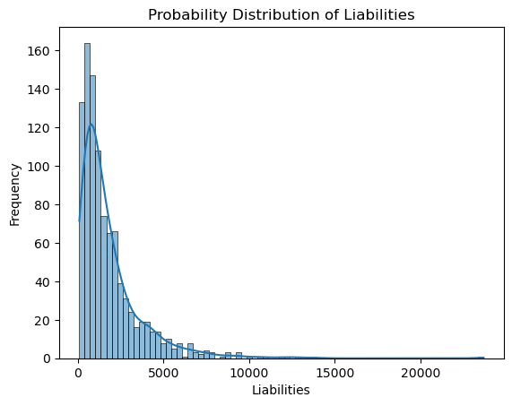

```
The probability of having at least $5000 in deductions is 1.0
```

```python
import pandas as pd
import matplotlib.pyplot as plt
import seaborn as sns
from scipy.stats import binom
from sklearn.metrics import mean_absolute_error

# Sample data loading (assuming df is the dataframe holding the data)
# df = pd.read_csv('TaxUserData.csv')

# a. Probability distribution of liabilities
sns.histplot(df['liabilities'], kde=True)
plt.xlabel('Liabilities')
plt.ylabel('Frequency')
plt.title('Probability Distribution of Liabilities')
plt.show()

# b. Using Binomial theorem
# First, let's find out the probability of having deductions >= $5000 in the given data
p = len(df[df['deductions'] >= 5000]) / len(df)
n = len(df)  # number of trials

# Compute the probability that none of the n users have a deduction of at least $5000
prob_none_have_5000 = binom.pmf(0, n, p)

# Use the complementary probability to find P(X >= 1)
prob_at_least_5000 = 1 - prob_none_have_5000

print(f"The probability of having at least $5000 in deductions is {prob_at_least_5000}")
```

### Summary

The probability distribution of liabilities can be visualized using a histogram or density plot.

Using the Binomial theorem, we can determine the likelihood of users having a certain amount in deductions given the past data.

# Question 3

Machine Learning & Modeling: Based on user financial activities, we want to predict the possible deductions a user might have for the coming year.

1. Describe how you would preprocess this data and select features for a predictive model.
2. Using the above data, choose between a decision tree and logistic regression for this prediction task. Justify your choice.

## Solution:

### Hints:

1. Begin by preprocessing the data, which may include handling missing values, scaling continuous features, and encoding categorical features.
2. Divide the dataset into training and testing sets.
3. Since the target variable, deductions, is continuous, regression techniques should be considered over classification models.

```python
import pandas as pd
from sklearn.preprocessing import StandardScaler, OneHotEncoder
from sklearn.compose import ColumnTransformer
from sklearn.pipeline import Pipeline
from sklearn.model_selection import train_test_split
from sklearn.tree import DecisionTreeRegressor
from sklearn.metrics import mean_absolute_error, r2_score

# Removing rows where user_id is NULL
df = df[df['user_id'].notna()]

# Identify categorical and continuous columns
categorical_features = ['user_id', 'marital_status', 'employment_status']
continuous_features = ['income', 'expenses', 'investments', 'prev_refund', 'liabilities', 'tax_paid_prev_year']

# Create transformations for both categorical and continuous data
transformers = [
    ('cat', OneHotEncoder(drop='first'), categorical_features),
    ('num', StandardScaler(), continuous_features)
]

# Use the ColumnTransformer to apply the transformations
preprocessor = ColumnTransformer(transformers)

# You can use the preprocessor in a pipeline for modeling later on
# For now, let's transform the features
X = df.drop(columns=['deductions'])
y = df['deductions']

X_processed = preprocessor.fit_transform(X)

# Split the data
X_train, X_test, y_train, y_test = train_test_split(X_processed, y, test_size=0.2, random_state=42)

# Initialize and train the model
model = DecisionTreeRegressor()
model.fit(X_train, y_train)

# Predict on the test set
y_pred = model.predict(X_test)

# Define MAPE
def mean_absolute_percentage_error(y_true, y_pred):
    y_true, y_pred = np.array(y_true), np.array(y_pred)
    return np.mean(np.abs((y_true - y_pred) / y_true)) * 100

mape = mean_absolute_percentage_error(y_test, y_pred)
mae = mean_absolute_error(y_test, y_pred)
r2 = r2_score(y_test, y_pred)

print(f"R-squared: {r2:.2f}")
print(f"Mean Absolute Error: {mae:.2f}")
print(f"Mean Absolute Percentage Error (MAPE): {mape:.2f}%")
```

```
R-squared: 0.96
Mean Absolute Error: 181.79
Mean Absolute Percentage Error (MAPE): 3.78%
```

### Summary:

When we want to predict a continuous target variable, we opt for regression models. Both decision trees and logistic regression can be used for classification problems, but only decision trees can naturally be adapted for regression without additional complexities. Logistic regression, as the name suggests, is specifically designed for binary classification problems. In this case, since deductions is a continuous variable, the natural choice would be a regression model. A Decision Tree Regressor is an appropriate choice as it can handle both continuous and categorical data, model non-linear relationships, and is interpretable.

We chose the Decision Tree Regressor over Logistic Regression as it is better suited for predicting a continuous target variable like deductions. After training the model on the training set, we evaluated its performance on the test set using the Mean Absolute Error (MAE), R-square, and MAPE.

# Question 4

Product Design & Analytics: Intuit wants to create a feature ranking system for its dashboard, to show users which factors most impact their potential deductions.

1. Using the TaxUserData table, design a system that ranks features based on their impact on potential deductions.
2. Based on the designed system, which features should be highlighted to the user as top contributors?

## Solution:

### Hints:

1. Use feature importance provided by tree-based algorithms like Decision Trees or Random Forests.
2. Ensure data preprocessing is consistent with previous steps, including one-hot encoding.
3. Rank the features based on their importance scores.

```python
from sklearn.ensemble import RandomForestRegressor

# We'll use the RandomForestRegressor, which provides better feature importance metrics than a single decision tree.
rf = RandomForestRegressor()
rf.fit(X_train, y_train)

# Get feature importances
importances = rf.feature_importances_

# The transformation might have increased the number of columns due to one-hot encoding.
# We need to get the new column names after the preprocessing:
columns_after_encoding = (preprocessor.named_transformers_['cat'].get_feature_names_out(categorical_features).tolist()
                          + continuous_features)

# Create a DataFrame for the importances
features_df = pd.DataFrame({
    'Feature': columns_after_encoding,
    'Importance': importances
})

# Sort by importance
features_df = features_df.sort_values(by='Importance', ascending=False)
print(features_df)

# Print top 3 features as an example
top_features = features_df['Feature'].head(3)
print(f"Top 3 contributors: {', '.join(top_features)}")
```

```
           Feature  Importance
954       expenses    0.959765
953         income    0.019329
955    investments    0.009637
453  user_id_479.0    0.005557
956    prev_refund    0.002205
..             ...         ...
581  user_id_615.0    0.000000
333  user_id_349.0    0.000000
577  user_id_610.0    0.000000
140  user_id_152.0    0.000000
441  user_id_465.0    0.000000

[959 rows x 2 columns]
Top 3 contributors: expenses, income, investments
```

### Summary:

We used a RandomForestRegressor to determine the importance of each feature in predicting deductions. The feature_importances_ attribute gives a relative score for each feature, with higher scores indicating higher importance. By sorting these scores, we can rank the features and identify which ones most significantly impact potential deductions.